# *England report*

## England report April 2019

This report is generated using information on a **sample** of drugs prescriptions in primary care in *England* for the month April 2019.

The report is parametrized using parameters reported in the **YAML** section of the Rmd and executed by *Cristina Muschitiello*.

You can change *month*, *year* and *executor* name of the present report, by changing the values of the corresponding `params` in the **YAML** section.

## Data description

The dataset used for this report are obtained from **NHS** Presentation Level prescription data. This dataset provides information on **all individual prescription** of **drugs and appliances** provided in **primary care** in *England*

The dataset is quite rich, with monthly data running from sept. 2011. Each month is about 1.5Gb. For a sample period (2018 and 2019) this dataset is made available using the **PrescRiptions** package which will be introduced in later sections.

Because running test on such large dataset might cause problems, the package allow for the usage of complete data or *sample* data. The present report is produced on a sample of 500.000 data rows from the complete dataset.

The type of information included in the data are:

```r
head(get(settings$plpdName))
```

```
##    SHA PCT PRACTICE        BNF.CODE                                 BNF.NAME
## 1: Q44 01C   N81002 0101021B0AAALAL            Sod Algin/Pot Bicarb_Susp S/F
## 2: Q44 01C   N81002 0101021B0AAAPAP  Sod Alginate/Pot Bicarb_Tab Chble 500mg
## 3: Q44 01C   N81002 0101021B0BEACAH         Gaviscon_Liq Orig Aniseed Relief
## 4: Q44 01C   N81002 0101021B0BEADAJ            Gaviscon Infant_Oral Pdr Sach
## 5: Q44 01C   N81002 0101021B0BEAIAL Gaviscon Advance_Liq (Aniseed) (Reckitt)
## 6: Q44 01C   N81002 0101021B0BEAQAP Gaviscon Advance_Tab Chble Mint(Reckitt)
##    ITEMS   NIC ACT.COST QUANTITY PERIOD
## 1:     2 15.36    14.30     1500 201904
## 2:     2  6.14     5.73      120 201904
## 3:     1 14.22    13.22     1200 201904
## 4:     4 77.12    71.70      240 201904
## 5:    14 73.65    68.90     6200 201904
## 6:     2  7.53     7.02       84 201904
```

## Summary stats

| rn | ITEMS | NIC | ACT.COST | QUANTITY |
| --- | --- | --- | --- | --- |
| Min. | 1 | 0 | 0 | 0.94 |
| 1st Qu. | 1 | 8.97 | 8.44 | 28 |
| Median | 2 | 25.29 | 23.73 | 90 |
| Mean | 10.546536 | 77.7797933 | 72.6811134 | 755.04597128 |
| 3rd Qu. | 6 | 69.66 | 65.1125 | 338 |
| Max. | 2082 | 25560.8 | 23858.79 | 783813 |

## Cost Distribution

We check the distribution of Net Ingredient Costs aggregated across practices

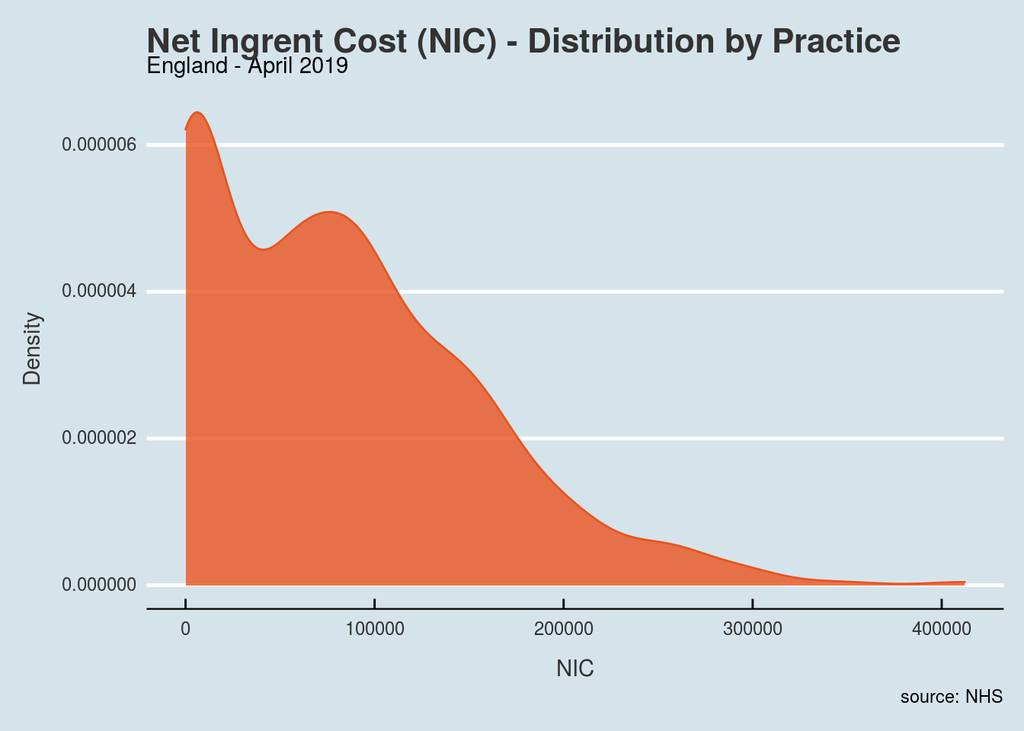

## Prescription rates

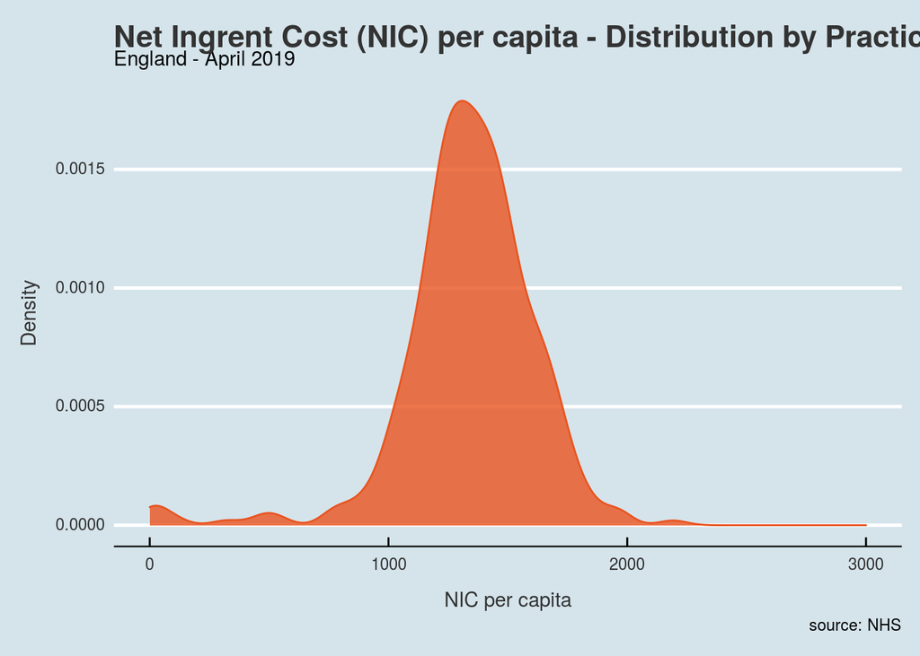

The figure above uses Net Ingredient Costs (NIC) computed as a rate per capita. The distribution looks much clearer now!

## High NIC per capita practices

We now identify practices with high Net Ingredient Costs (NIC) per patient. For simplicity, we select as high-prescribing those practices who are in the top 5% for the NIC per capita.

| PRACTICE | tot_NIC | NUMBER_OF_PATIENTS | NIC_rate |
| --- | --- | --- | --- |
| A81053 | 117040.54 | 6472 | 1808.41378244747 |
| A81630 | 66460.88 | 812 | 8184.83743842365 |
| A81632 | 1763.92 | 37 | 4767.35135135135 |
| A83023 | 202696.58 | 11601 | 1747.23368675114 |
| A83024 | 101168.12 | 5634 | 1795.67128150515 |
| A83037 | 257470.07 | 13909 | 1851.10410525559 |
| A83041 | 137928.74 | 7533 | 1830.9934952874 |
| A83617 | 46626.28 | 2623 | 1777.59359512009 |
| A83634 | 53652.39 | 2752 | 1949.578125 |
| A83637 | 46226.91 | 2109 | 2191.88762446657 |

[output cut: 8 more lines]

The table above indicates basic information of high-NIC per capita practices.